# 응용데이터사이언스: 세 번째 수업

김권현

2018년 9월 28일

# 오늘 수업의 주요 내용

- 지난 시간의 소개한 Simpson’s paradox과 새로 소개하는 Berkson’s paradox
- R로 데이터 읽어오기
- 데이터 살펴보기
- R의 데이터 타입 : numeric(수치형), character(문자열), factor/ordered(범주형,순위형)[^1]
- 그밖에 : 조 구성, 발표 순번 결정

## 데이터 살펴보기

데이터를 전체적으로 살펴보고 분석의 방향을 가늠한다. 이 과정에서 자료의 오류를 찾을 수도 있다. 특히 특이값(outlier)과 결측값(missing value)에 주목한다.

> 데이터에는 크고 작은 오류가 있기 마련이다.
- 데이터 프레임`df`의 전체적인 구조 확인하기

```r
df <- mtcars
head(df, n=10); tail(df); View(df)
dim(df); nrow(df); ncol(df)
colnames(df); rownames(df)
apply(df, 2, function(x) sum(is.na(x)))
sum(duplicated(df))
sum(!complete.cases(df))
```

- 통계 요약치
  - 집중경향치 : 평균(mean), 중앙값(median), 최빈값(mode), 절사평균(trimmed mean)
  - 변산성 측정치 : 범위(range), 사분점간 범위(inter-quartile range), 분산(variance), 표준편차(standard deviation)
- 데이터 시각화
  - 1변수 시각화 : 이산형 데이터(`plot`), 연속형 데이터(`hist`)
  - 2변수 시각화 : `plot(y ~ x, data = )`
  - 조건부 시각화 : `xyplot(y ~ x | g, data = )`

### 통계요약치

```r
x <- rnorm(100)
x <- c(x, 2, 2)

# 집중경향치
mean(x)
median(x)
Mode <- function(x) {
  ux <- unique(x)
  ux[which.max(tabulate(match(x, ux)))]
}
Mode(x) # table
mean(x, trim = 0.2)

# 변산성 측정치
range(x)
IQR(x)
var(x)
sd(x)
```

함수 `Mode`는 [stackoverflow](https://stackoverflow.com/questions/2547402/is-there-a-built-in-function-for-finding-the-mode)에서 가져왔다.

주어진 데이터 프레임의 모든 열에 대해 요약통계치를 얻으려면 `apply(df, 2, func)`을 사용한다.

```r
data(mtcars)
apply(mtcars, 2, mean)

data("BankWages", package='AER')
apply(BankWages, 2, Mode)
```

R에는 좀 더 간단한 함수를 제공한다. `summary`, `psych::describe`등을 활용해보자.

```r
data('singer', package='lattice')
summary(mtcars)
summary(BankWages)
summary(singer)
```

### 데이터시각화

- 1변수의 시각화
  - 이산형 : `plot`
  - 연속형 : `hist`
- 2변수의 시각화
  - `plot(y ~ x, data= )`
- 조건부 1변수 시각화
  - 이산형 : `lattice::histogram(~ x | g, data= )`
  - 연속형 : `lattice::histogram(~ x | g, data= )`
- 조건부 2변수 시각화
  - `x`, `y` 이산형 : `lattice::histogram(~ y | x*g, data = )`
  - `x` 이산형, `y` 연속형 : `lattice::xyplot(y ~ x | g, data = , jitter.x = TRUE)`
  - `x`, `y` 연속형 : `lattice::xyplot()`[^2]

### 시각화 결과

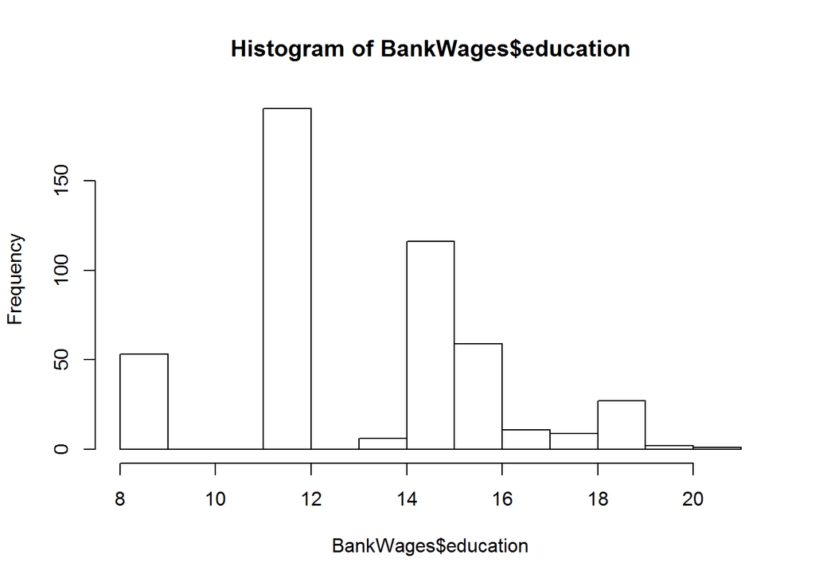

```r
library(lattice)
data('BankWages', package='AER')
data(mtcars)
# 일변수
hist(BankWages$education) #histogram(~education, data=BankWages)
```

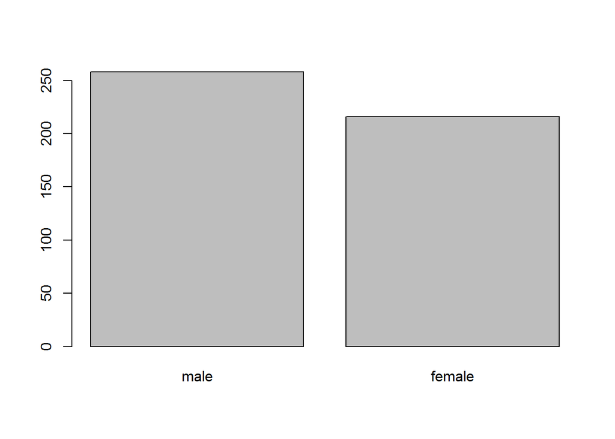

```r
plot( ~ gender, data=BankWages)
```

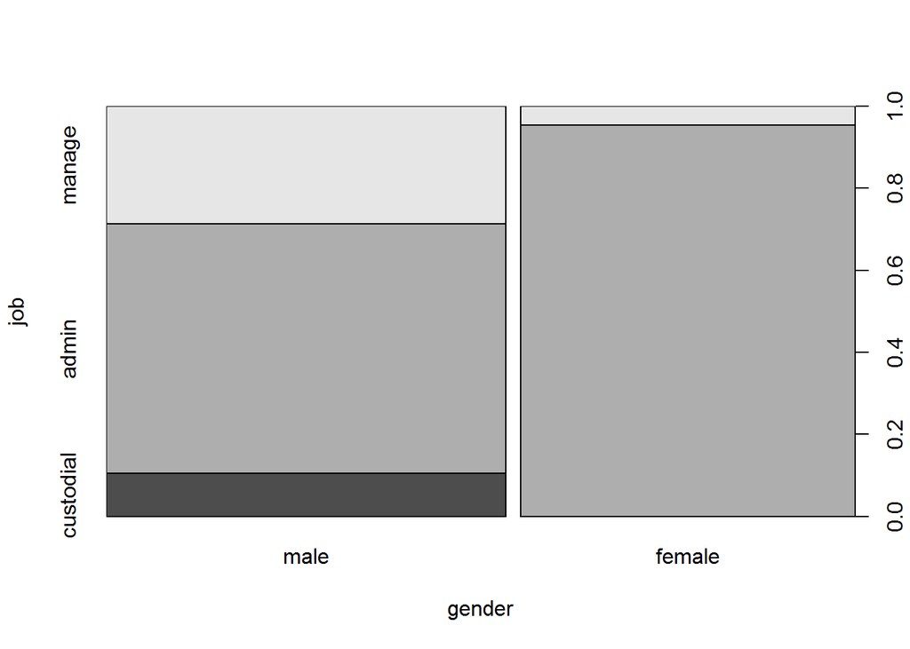

```r
# 이변수
plot(job ~ gender, data=BankWages)
```

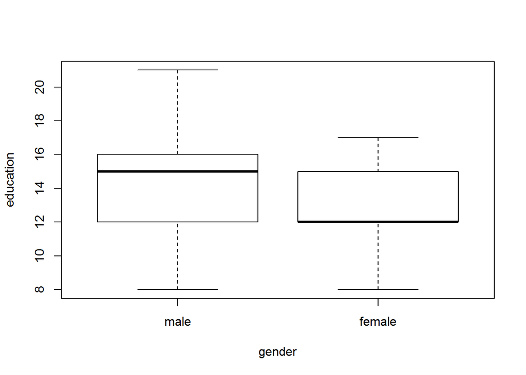

```r
plot(education ~ gender, data=BankWages)
```

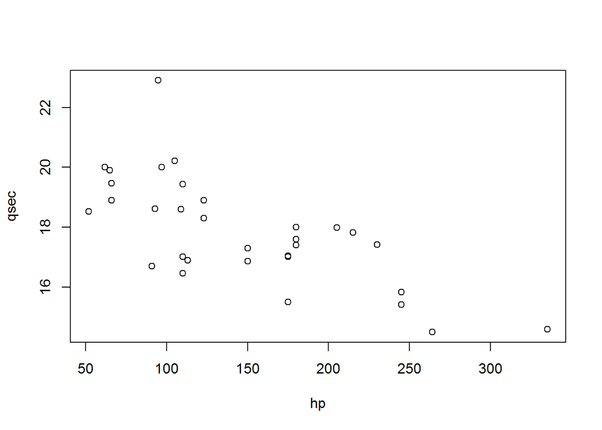

```r
plot(qsec ~ hp, mtcars)
```

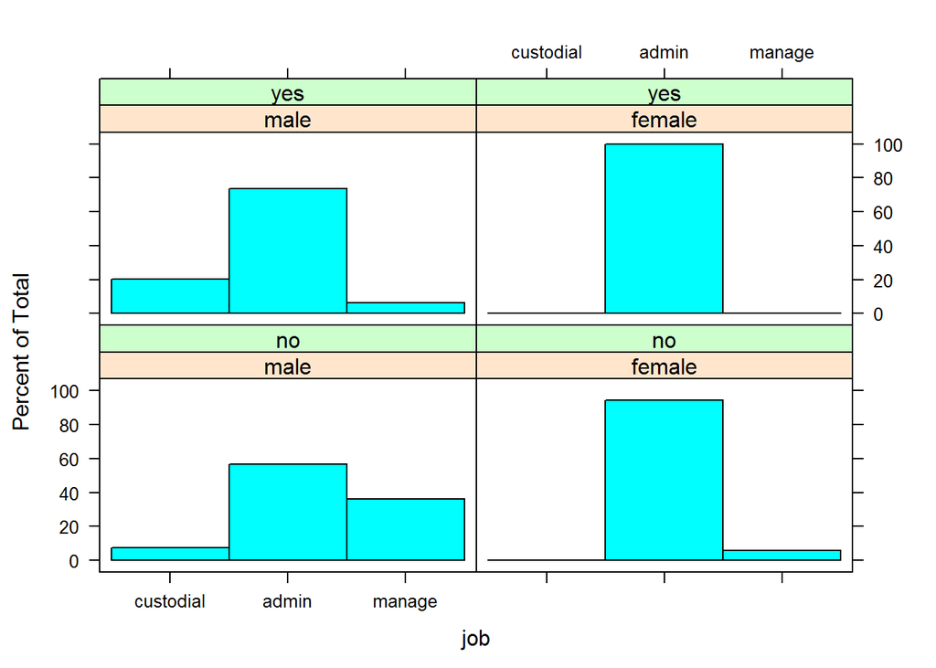

```r
# 조건부 플롯
histogram( ~ job | gender * minority, BankWages)
```

```r
library(dplyr)
```

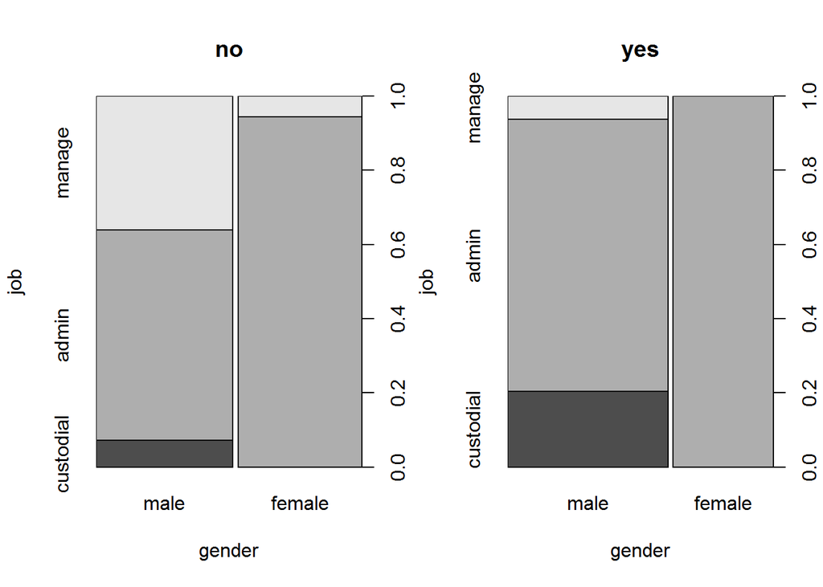

```
## # A tibble: 0 x 1
## # Groups:   minority [0]
## # ... with 1 variable: minority <fct>
```

```r
par(mfcol=c(1,2))
BankWages %>% group_by(minority) %>% do({
  plot(job~gender, main = .$minority[1], data=.)
  data.frame()
})
```

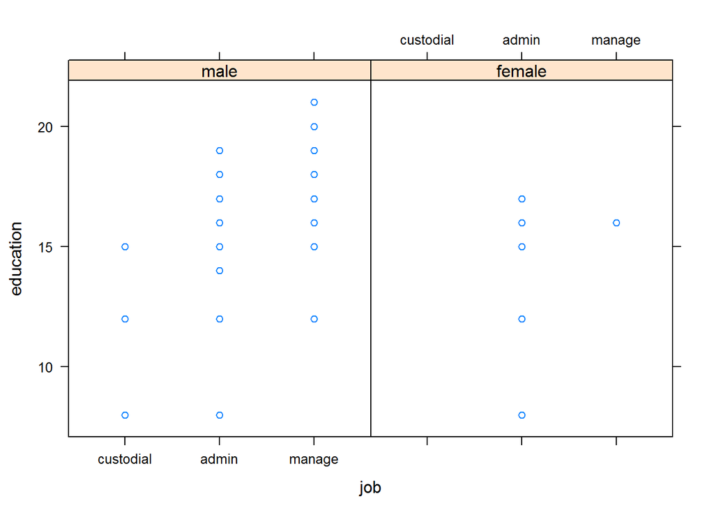

```r
xyplot(education ~ job | gender, BankWages)
```

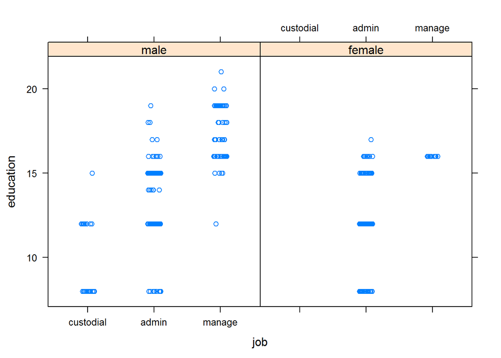

```r
xyplot(education ~ job | gender, BankWages, jitter.x=TRUE)
```

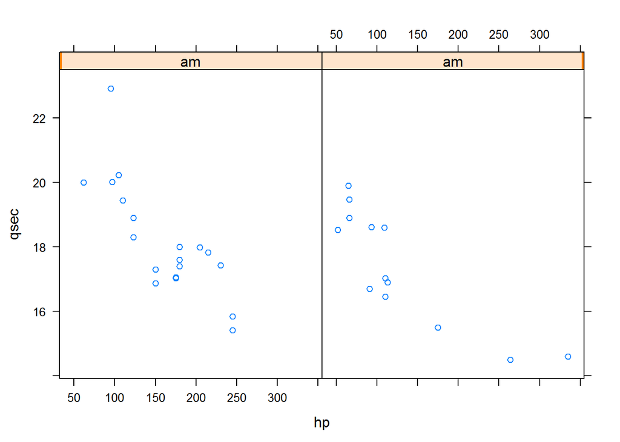

```r
xyplot(qsec ~ hp | am, mtcars)
```

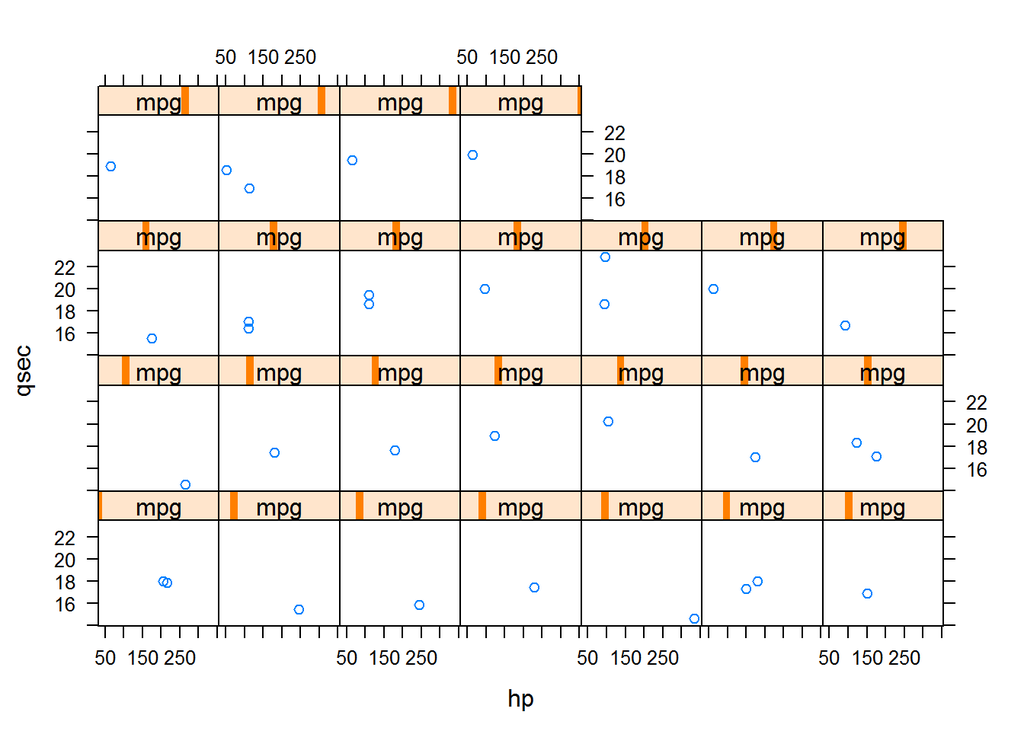

```r
xyplot(qsec ~ hp | mpg, mtcars)
```

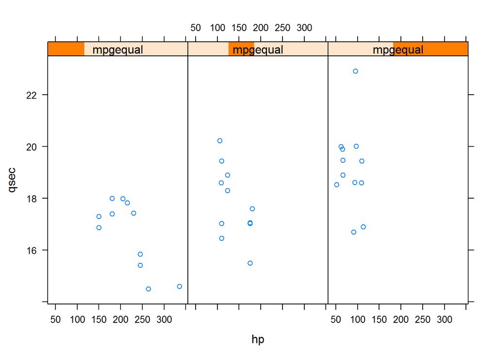

```r
mpgequal <- equal.count(mtcars$mpg, number=3, overlap=0)
xyplot(qsec ~ hp | mpgequal, mtcars)
```

[^1]: 측정척도(scales of measurement)는 ’대상들에 부여한 숫자들의 관계의 특징’이다. 예를 들어 다음의 세 질문에 답해보자. 1) 수영대회에서 당신의 등번호는? 2) 수영대회에서 당신의 등수는? 3) 수영장을 한 번 도는 데 몇 초 걸렸나요? 이들은 1) 명명척도(nominal scale), 2) 서열척도(ordinal scale), 3) 비율척도(ratio scale)의 예이다. 그 외에도 간격척도(interval scale)가 있다.